# Burgernomics & Kaufkraft: Was uns der Big-Mac-Index über Währungen und Wohlstand verrät

Luc Benjamin Keim, Jannick Riond

29.05.2025

## 2 Datengrundlage

### 2.1 Verwendete R-Pakete

```r
library(tidyverse)
library(dslabs)
library(countrycode)
library(readxl)
```

### 2.2 Datenstruktur

Der Datensatz `grundlage_f` enthält folgende relevante Variabeln:

- `local_price`: BigMac Preis in lokaler Währung
- `currency_code`: Währungscode (z.B. USD, EUR)
- `dollar_ex`: Wechselkurs zum US-Dollar
- `gdp_per_capita`: Bruttoinlandprodukt pro Kopf
- `Country`: Ländername

### 2.3 Laden des Datensatzes

```r
grundlage_f <- read_xlsx("C:\\Users\\riond\\Desktop\\grundlage_f.xlsx")
```

### 2.4 Konfiguration

Mit dem Befehl `view(grundlage_f)` können wir unsere Tabelle anschauen, um zu prüfen, ob sie vollständig und richtig importiert wurde.

In unserem Fall müssen wir die wissenschaftliche Notation deaktivieren, um die Zahlen besser lesen zu können.

```r
options(scipen = 999)  # Deaktiviert wissenschaftliche Notation
```

## 3 Datenaufbereitung und Berechnung

### 3.1 Referenzwert etablieren

Um Preise verschiedener Länder miteinander vergleichen zu können, benötigen wir einen gemeinsamen Bezugspunkt. Ähnlich wie im Physikunterricht, wo beispielsweise alle Gewichtsangaben zunächst in kg umgewandelt werden müssen, bevor man sie miteinander verrechnen oder vergleichen kann.

Der Big Mac Index wurde ursprünglich von *The Economist*, einem amerikanischen Wirschaftsmagazin, entwickelt und nutzt bewusst den US-amerikanischen Big Mac Preis als “Weltstandard”. Aus diesem Grund haben wir uns ebenfalls dazu entschieden den US-Dollar als Referenzwert zu verwenden.

```r
# Preis eines US-Big-Macs (laut Tabelle, Zeile 51, Spalte 4)
price_usa <- grundlage_f$local_price[grundlage_f$currency_code == "USD"]
```

### 3.2 Berechnung ökonomischer Indikatoren

#### 3.2.1 Begriffe: Kaufkraft, PPP, GDP

Damit wir die ökonomischen Indikatoren berechnen können, müssen wir zunächst ein paar Begriffe erklären:

> Die **Kaufkraft** (engl.: **“Purchasing Power”**) beschreibt die Menge an Waren und Dienstleistungen, die mit einer bestimmten Geldsumme zu einem gegebenen Zeitpunkt erworben werden kann; sie spiegelt somit den realen Wert des Geldes wider und sinkt bei steigenden Preisen (Inflation) bzw. steigt bei fallenden Preisen (Deflation).

> **Kaufkraftparität** (engl.: **“Purchasing Power Parity”**, **PPP**) ist das theoretische Konzept, nach dem Wechselkurse sich langfristig so einstellen, dass ein identischer Waren- und Dienstleistungskorb in verschiedenen Ländern, nach Umrechnung in eine gemeinsame Währung, denselben Preis hat; Abweichungen davon erklären Unterschiede im Preisniveau bzw. in den Inflationsraten der Länder.

> Das **Bruttoinlandprodukt** (**BIP**, engl.: **“Gross Domestic Product”**, **GDP**) ist der Gesamtwert aller in einer Volkswirtschaft innerhalb eines bestimmten Zeitraums (meist eines Jahres) produzierten Waren und Dienstleistungen zu Marktpreisen. Es dient als zentrale Messgrösse für die wirtschaftliche Leistung eines Landes.

#### 3.2.2 Mathematische Formeln der berechneten Variabeln

Der **BigMac-Preis in US-Dollar** ($P_{\text{USD}}$, auch `dollar_price`) berechnet sich wie folgt:

$$P_{\text{USD}} =
\frac{P_{\text{local}}}{E_{\text{USD}}}$$
wobei

- $P_{\text{local}}$ den lokalen Preis eines BigMacs im jeweiligen Land (`local_price`) angibt und
- $E_{\text{USD}}$ den Wechselkurs zur Referenzwährung US-Dollar (`dollar_ex`) bezeichnet.

Das **Kaufkraftparitätsverhältnis** des BigMacs ($PPP_{\text{BigMac}}$, auch `dollar_ppp`) gibt an, wie sich der Preis eines BigMacs im jeweiligen Land zum Preis in den USA verhält. Es wird folgendermassen berechnet:

$$PPP_{\text{BigMac}} =
\frac{P_{\text{local}}}{P_{\text{USA}}}$$
Hierbei steht

- $P_{\text{USA}}$ für den lokalen BigMac-Preis in den USA.

Ein Wert von $PPP_{\text{BigMac}} > 1$ weist darauf hin, dass der BigMac im betrachteten Land teurer ist als in den USA (Überbewertung), während ein Wert $PPP_{\text{BigMac}} < 1$ eine Unterbewertung suggeriert.

Die Frage, **wie viele Big Macs sich eine durchschnittliche Person mit dem nationalen BIP pro Kopf leisten könnte**, beantwortet die folgende Formel:

$$\text{BigMac}_\text{GDP} =
\frac{\text{GDP}_\text{per capita}}{P_\text{USD}}$$
Dabei bezeichnet

- $\text{GDP}_\text{per capita}$ das Bruttoinlandsprodukt pro Kopf und
- $P_\text{USD}$ den umgerechneten BigMac-Preis in US-Dollar.

Dieser Wert quantifiziert, wie viele Big Macs eine Person im jeweiligen Land (theoretisch!) im Jahr kaufen könnte, unter der Annahme, dass das BIP pro Kopf gleichmässig auf alle Einwohner*innen verteilt wäre.

#### 3.2.3 Code für die Indikatoren

```r
# Alle Berechnungen in einer Pipeline
bmf <- grundlage_f %>%
  mutate(
    dollar_price = local_price / dollar_ex,
    dollar_ppp = local_price / price_usa,
    bigmac_gdp = gdp_per_capita / dollar_price)
```

### 3.3 Datenbereinigung

Die Euro Area als Wirtschaftsraum wird entfernt, da sie kein einzelnes Land darstellt.

```r
bmf <- bmf[-16, ]
```

## 4 Datenanalyse und Visualisierung

### 4.1 Kontinentale Verteilungsanalyse

Vergleich der BigMac-Kaufkraft ($\text{BigMac}_\text{GDP}$, auch `bigmac_gdp`) zwischen verschiedenen Kontinenten mittels Boxplot-Darstellung zur Identifikation von Verteilungsmustern und Ausreissern.

[figure not shown]

```r
bmf$continent <- countrycode(sourcevar = bmf$Country,
                             origin = "country.name",
                             destination = "continent")

ggplot(bmf, aes(x = continent, y = bigmac_gdp, fill = continent)) +
  geom_boxplot() +
  labs(title = "Bigmac-GDP nach Kontinent",
       x = "Kontinent", y = "Bigmacs pro Kopf")
```

### 4.2 Korrelationsanalyse

#### 4.2.1 Korrelationskoeffizient

In diesem Abschnitt untersuchen wir, wie stark der Zusammenhang zwischen zwei Variablen (`gdp_per_capita` und `bigmac_gdp`) ist:

Wobei:

- $r = 1$ eine perfekten postivien Zusammenhang darstellt,
- $r = 0$ keinen linearen Zusammenhang und
- $r = -1$ einen perfekten negativen Zusammenhang darstellt.

In R können wir das viel einfacher mit folgender Funktion ausrechnen:

```r
cor(bmf$gdp_per_capita, bmf$bigmac_gdp, use = "complete.obs")
```

```
## [1] 0.9195871
```

In unserem Fall ist $r = 0.9195871$.

Interpretation: Es besteht ein sehr starker, positiver Zusammenhang zwischen dem BIP pro Kopf und dem BigMac-GDP.

#### 4.2.2 Lineare Regression

Während die Korrelation nur die Stärke des Zusammenhangs beschreibt, zeigt die **lineare Regression** auch, wie die eine Variable die andere „vorhersagt“. Das Ergebnis ist eine sogenannte **Regressionsgerade**, die man auch in Diagrammen einzeichnen kann.

Eine lineare Gleichung kennen wir als:

$$y = mx + b$$

Ein lineares Regressionsmodell wird häufig so formuliert:

$$\hat{y}_i = \beta_1 x_i +
\beta_0$$

Die gesuchte Gerade soll so gewählt werden, dass die quadrierten Abstände zwischen den durch das Modell vorhergesagten und den empirisch beobachteten Werten minimiert werden; es soll also gelten:

$$\sum_{i=1}^{n}{{\varepsilon_i}^2} =
\sum_{i=1}^{n}{(y_i - \hat{y_i})^2} = \text{Minimum}$$
Der Fehlerwert $\varepsilon$ ergibt sich also aus:

$$\varepsilon_i = y_i -
\hat{y_i}$$

Unser Regressionsmodell lässt demnach wie folgt formulieren, wobei $\varepsilon$ zu minimieren ist.

$$\text{BigMac}_{GDP} = \beta_0 + \beta_1
\cdot \text{GDP}_{\text{per capita}} + \varepsilon$$

Da diese Minimierungsaufgabe rechnerisch eher anspruchsvoll ist, verwenden wir in R die `lm()`-Funktion.

```r
Regressionsgerade <- lm(bigmac_gdp ~ gdp_per_capita, data = bmf)
summary(Regressionsgerade)
```

```
##
## Call:
## lm(formula = bigmac_gdp ~ gdp_per_capita, data = bmf)
##
## Residuals:
##     Min      1Q  Median      3Q     Max
## -6574.1  -933.6  -416.9   400.9  7416.4
##
## Coefficients:
##                  Estimate Std. Error t value             Pr(>|t|)
## (Intercept)    1182.07948  427.59999   2.764              0.00792 **
## gdp_per_capita    0.17338    0.01037  16.715 < 0.0000000000000002 ***
## ---
## Signif. codes:  0 '***' 0.001 '**' 0.01 '*' 0.05 '.' 0.1 ' ' 1
##
## Residual standard error: 2134 on 51 degrees of freedom
## Multiple R-squared:  0.8456, Adjusted R-squared:  0.8426
## F-statistic: 279.4 on 1 and 51 DF,  p-value: < 0.00000000000000022
```

Aus der Konsole lassen sich nun unsere Resultate ablesen.

Wir erhalten

- $\beta_0 = 1182.07948$ und
- $\beta_1 = 0.17338$.

#### 4.2.3 Scatterplot mit Regressionsgerade

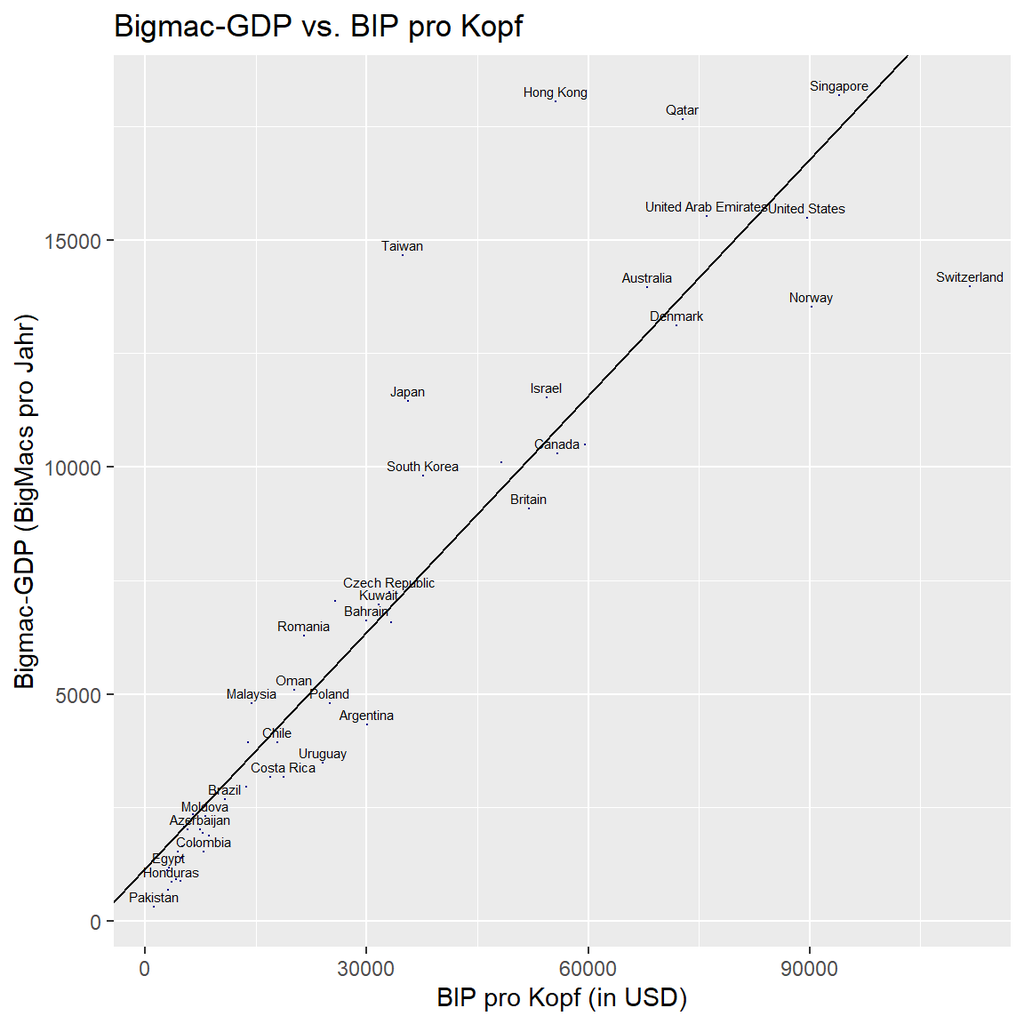

```r
ggplot(bmf, aes(x = gdp_per_capita, y = bigmac_gdp, label = Country)) +
  geom_point(color = "darkblue", size = 0.1) +
  geom_text(size = 2, vjust = -0.5, check_overlap = TRUE) +
  labs(title = "Bigmac-GDP vs. BIP pro Kopf",
       x = "BIP pro Kopf (in USD)", y = "Bigmac-GDP (BigMacs pro Jahr)") +
  geom_abline(intercept = 1182.0748, slope = 0.17338)
```

### 4.3 Anwendungsspezifische Analyse: Die idealen Reiseziele

#### 4.3.1 Filterkriterien

$$S = {\text{Land}_i : P_{\text{USD},i}
\leq 4.5 \land \text{GDP}_{\text{per capita},i} > 30000}$$

```r
guter_ferienort <- bmf %>%
  filter(dollar_price <= 4.5) %>%  # Günstige BigMac Preise
  filter(gdp_per_capita > 30000)   # Hohe wirtschaftliche Entwicklung
```

#### 4.3.2 Ergebnisvisualisierung

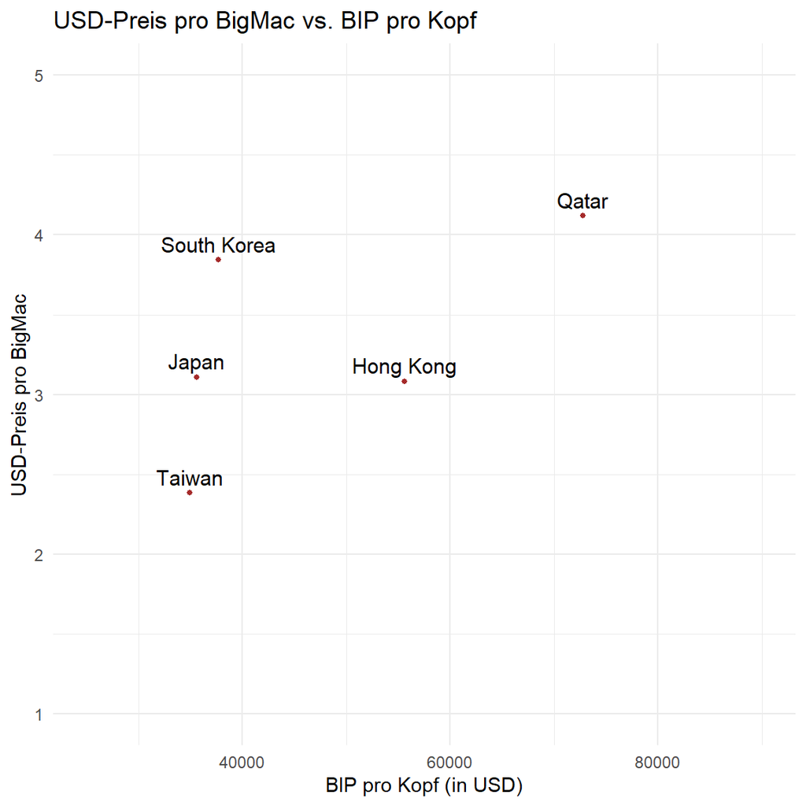

```r
ggplot(guter_ferienort, aes(x = gdp_per_capita, y = dollar_price, label= Country))+
  geom_point(color = "brown", size=1)+
  geom_text(size=4, vjust= -0.5, check_overlap = TRUE)+
  theme_minimal()+
  labs(title = "USD-Preis pro BigMac vs. BIP pro Kopf",
       x = "BIP pro Kopf (in USD)", y = "USD-Preis pro BigMac")+
  xlim(25000, 90000)+
  ylim(1, 5)
```

## Quellen

„Big Mac Index“. 2025. In *Wikipedia*. https://en.wikipedia.org/w/index.php?title=Big_Mac_Index&oldid=1273939978.

„Bruttoinlandsprodukt“. 2025. In *Wikipedia*. https://de.wikipedia.org/w/index.php?title=Bruttoinlandsprodukt&oldid=256050843.

Evan Hensleigh. (2018) 2025. „TheEconomist/Big-Mac-Data“. The Economist. https://github.com/TheEconomist/big-mac-data.

„Lineare Regression“. 2025. In *Wikipedia*. https://de.wikipedia.org/w/index.php?title=Lineare_Regression&oldid=253644738.

„World Bank Open Data“. o. J. World Bank Open Data. Zugegriffen 27. Mai 2025. https://data.worldbank.org.

## GitHub

Das *.rmd*-File sowie das *.html*- und das *.pdf*-File sind auf GitHub einsehbar unter:

https://github.com/jannickr2j1/AwM_RProjekt_BigMac